# Aula 5 - Importação de dados (cont.), APIs

Rafael N. Magalhães

08 de março, 2019

## Programa

1. Uso da página institucional no Github
2. Exercício da semana passada
3. Importação de arquivos `.csv`
4. Importação de dados do Excel
5. Uso de APIs

## Esquema do curso

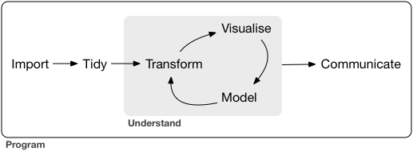

## Importação de dados

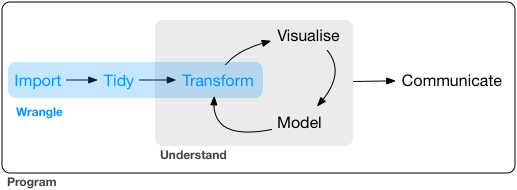

# Importação de arquivos .csv

## Importando bancos em formato .csv

O formato mais flexível de distribuição de bases de dados é o `csv`. Trata-se de um arquivo de texto sem estrutura proprietária, podendo, portanto, ser usado em qualquer pacote estatístico.

Duas fontes de dados importantes são o [CIS-USP](http://www.nadd.prp.usp.br/cis/index.aspx) e o [Cesop-Unicamp](https://www.cesop.unicamp.br/por). Ambos disponibilizam diversas bases de dados gratuitas, basta criar um cadastro. Ao longo do curso vamos conhecer outras bases de dados importantes.

Vamos usar um arquivo que baixei do site do CIS: a [avaliação da população sobre o Mensalão](http://www.nadd.prp.usp.br/cis/DetalheBancoDados.aspx?cod=B539&lng=pt-br). Vocês receberam o arquivo `csv` por e-mail. *Baixe-o no seu diretório de trabalho*.

## Importando bancos em formato .csv

Importaremos o arquivo com o pacote readr

```r
# install.packages("readr")
library(readr)
```

Como todo arquivo `.csv`, nosso banco de dados é delimitado por caracteres especiais. Note que na função abaixo estamos especificando `;` como o delimitador

```r
bd_csv <- read_delim("BD_CIS0539.csv", ";", escape_double = FALSE, trim_ws = TRUE)
View(bd_csv)
```

## Importando bancos em formato .csv

Com pacotes especializados, também podemos importar bases de dados do Excel e de outros pacotes estatísticos, como o SPSS. Veremos como usar esses pacotes nas próximas aulas.

Vocês perceberam que os nomes de algumas variáveis nesse banco de dados indicam o número da pergunta, e não que pergunta foi feita. Você pode consultar o questionário (também enviado por e-mail) para verificar do que se trata a pergunta 2, por exemplo.

Por exemplo, para ver a distribuição de preferências partidárias, podemos usar o comando `table()`

```r
table(bd_csv$PARTIDO)
```

Nas próximas aulas veremos como limpar essa base de dados (tratamento de NAs, por exemplo), e como tratar de bases de dados mais bagunçadas.

# Importação de arquivos em Excel

## Importação de arquivos em Excel

A lógica é muito parecida com a importação de arquivos `.csv`. Apenas usaremos um pacote diferente:

```r
# install.packages("readxl")
library(readxl)
bd_excel <- read_excel("BD_CIS0539.xlsx")
View(bd_excel)
```

É boa prática usar, na medida do possível, formatos de dados como o `.csv`, que possam ser lidos por um simples editor de texto.

No entanto, ainda é muito comum que dados sejam divulgados em formatos como o Excel, SPSS (nas ciências sociais) ou Stata (na economia)

# APIs

## APIs

A sigla API significa *Application Programming Interface*. Trata-se de uma interface de comunicação entre dois sistemas, com protocolos para facilitar a troca de informação de um ambiente para outro.

Do ponto de vista do nosso curso, o uso de APIs é importante porque facilita muito a obtenção dos dados. Com os pacotes corretos, podemos utilizar bases de dados sem precisar importá-los.

Isso pode parecer trivial agora, mas lembrem-se que, por enquanto, só mexemos com bases que já estão no formato **tidy**. Com bases mais complexas, as APIs podem nos economizar bastante tempo que seria utilizado com checagem dos dados e limpeza.

## Pacotes no R

Ao longo do curso vamos mexer com diversos pacotes relevantes para políticas públicas.

Alguns dos mais importantes são:

- [congressbr](https://cran.r-project.org/web/packages/congressbr/index.html): Votações nominais e estimação da probabilidade de um PL passar
- [electionsbr](https://cran.r-project.org/web/packages/electionsBR/index.html): Dados eleitorais gerais
- [cepespR](https://github.com/Cepesp-Fgv/cepesp-r): Dados eleitorais e socioeconômicos
- [BETS - Brazilian Economics Time Series](https://cran.r-project.org/web/packages/BETS/): Dados econômicos do IBGE, Banco Central e outras fontes

Há APIs para outros tipos de dados relevantes para o nosso trabalho. O pacote [twitteR](https://cran.r-project.org/web/packages/twitteR/index.html) permite coletar dados de engajamento na rede social e produzir análises de texto, sentimento, redes, etc. Vamos mexer bastante nele mais para a frente!

## Dados do Congresso

Por hoje vamos ter apenas um aperitivo de como funcionam esses pacotes. Assim que terminarmos os fundamentos, vamos voltar a eles para fazer análises aplicadas.

Vamos usar os comandos já conhecidos para instalar e carregar o pacote `congressbr`. Em seguida, vamos olhar os dados disponíveis para a votação do [PL 1992/2007](https://www.camara.leg.br/proposicoesWeb/fichadetramitacao?idProposicao=366851).

```r
# install.packages("congressbr")
library(congressbr)

# Informações sobre a votação 1992/2007
pl_1992 <- cham_votes(type = "PL", number = "1992", year = "2007")

# Todas as votações do ano passado
leis_2018 <- cham_plenary_bills(year = 2018)
```

## Dados do Congresso

Por fim, uma análise básica só para vocês verem como funciona.

Ainda não vimos muitos desses comandos, mas chegaremos lá em breve.

```r
# install.packages("ggplot2")
library(ggplot2)

party_orientation <- cham_votes(type = "PL", number = "1992", year = "2007")

# Selecionar apenas a linha que interessa e transpor os dados
party_orientation <- as.data.frame(t(party_orientation[1, c(7, 10:22)]))
names(party_orientation)[1] <- "orientation"
```

## Dados do Congresso

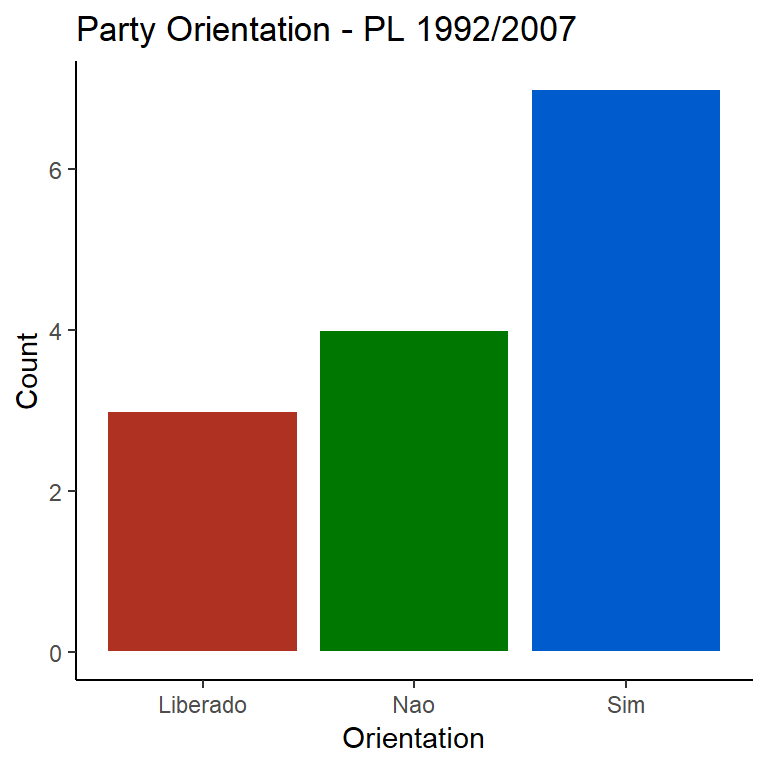

```r
ggplot(party_orientation, aes(x = orientation)) +
  geom_bar(aes(fill = orientation), colour = "white") +
  theme_classic() +
  scale_fill_hue(l = 40) +
  ggtitle("Party Orientation - PL 1992/2007") +
  labs(x = "Orientation", y = "Count") +
  theme(legend.position = "none")
```

## Dados do Senado

Agora, vamos explorar mais algumas funções do pacote, tomando como base o Senado:

```r
# Todas as votações nominais
data("sen_nominal_votes")
View(sen_nominal_votes)

# Informações sobre o voto de cada senador
votos_senado <- sen_votes(date = "20160908")

# Informações sobre a sessão
sessao_senado <- sen_plenary_result(date = "20160303")

# Informações osbre os senadores
senadores <- sen_senator_list()
```

## Dados do Senado

```r
# Dados sobre as comissões
data("commissions")
View(commissions)

# Componentes (atentar para atualização dos dados)
ccj <- sen_commissions_senators(code = "CCJ")

# Medidas provisórias em tramitação em 2001
medidas_provisorias <- sen_bills_passing(year = "2001", type = "MPV")

# Agenda do Senado
agenda <- sen_agenda(initial_date = "20161105", end_date = "20161125")
```

## Dados do Senado

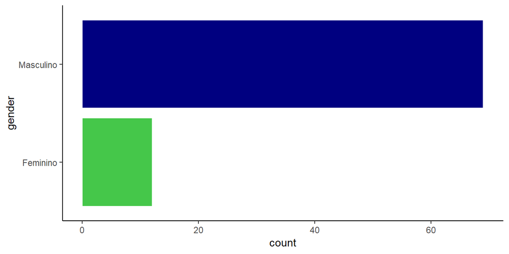

```r
# Distribuição dos senadores por sexo
senadores <- sen_senator_list()

ggplot(senadores, aes(x = gender)) +
  geom_bar(aes(fill = gender), colour = "white") +
  theme_classic() +
  theme(legend.position = "none") +
  scale_fill_manual(values = c("#45C74A", "navy")) +
  coord_flip()
```